# Ejercicios Tema 2 - Variables aleatorias. Soluciones.

Variables aleatorias

30 septiembre, 2024

# 1 Variables aleatorias discretas

## 1.1 Problema 1.

Hay 10 estudiantes inscritos en una clase de Estadística, de entre los cuales 3 tienen 19 años, 4 tienen 20 años, 1 tiene 21 años, 1 tiene 24 años y 1 tiene 26 años. De esta clase se seleccionan dos estudiantes sin reposición. Sea $X$ la edad media de los dos estudiantes seleccionados. Hallar la función de probabilidad para $X$.

### 1.1.1 Solución

Los valores que puede alcanzar $X$ son los siguientes:

- $X=19$ si se eligen los dos estudiantes de 19 años.
- $X=19.5$ si se elige un estudiante de 19 años y uno de 20 años.
- $X=20$ si se eligen los dos estudiantes de 20 años o un estudiante de 19 años y el otro de 21 años.
- $X=20.5$ si se elige un estudiante de 20 años y otro de 21 años.
- $X=21.5$ si se elige un estudiante de 19 años y otro de 24 años.
- $X=22$ si se elige un estudiante de 20 años y otro de 24 años.
- $X=22.5$ si se elige un estudiante de 19 años y otro de 26 años o un estudiante de 21 años y otro de 24 años.
- $X=23$ si se elige un estudiante de 20 años y otro de 26 años.
- $X=23.5$ si se elige un estudiante de 21 años y otro de 26 años.
- $X=25$ si se elige un estudiante de 24 años y otro de 26 años.

La función de probabilidad de $X$ es la siguiente:
$$P_X(x)=P(X=x)=\frac{\mbox{Casos favorables}}{\mbox{Casos posibles}}=
\left\{\begin{array}{ll}
\frac{\binom{3}{2}}{\binom{10}{2}}=\frac{3}{45}=0.0666667, &
\mbox{si } x=19,
\\[0.25cm]
\frac{3\cdot 4}{\binom{10}{2}}=\frac{12}{45}=0.2666667, & \mbox{si }
x=19.5,
\\[0.25cm]
\frac{\binom{4}{2}}{\binom{10}{2}}+\frac{3}{\binom{10}{2}}=\frac{6}{45}+\frac{3}{45}=0.2,
& \mbox{si } x=20,
\\[0.25cm]
\frac{4\cdot 1}{\binom{10}{2}}=\frac{4}{45}=0.0888889, & \mbox{si }
x=20.5,
\\[0.25cm]
\frac{3\cdot 1}{\binom{10}{2}}=\frac{3}{45}=0.0666667, & \mbox{si }
x=21.5,
\\[0.25cm]
\frac{4\cdot 1}{\binom{10}{2}}=\frac{4}{45}=0.0888889, & \mbox{si }
x=22,
\\[0.25cm]
\frac{3}{\binom{10}{2}}+\frac{1}{\binom{10}{2}}=\frac{3}{45}+\frac{1}{45}=0.0888889,
& \mbox{si } x=22.5,
\\[0.25cm]
\frac{4\cdot 1}{\binom{10}{2}}=\frac{4}{45}=0.0888889, & \mbox{si }
x=23,
\\[0.25cm]
\frac{1}{\binom{10}{2}}=\frac{1}{45}=0.0222222, & \mbox{si } x=23.5,
\\[0.25cm]
\frac{1}{\binom{10}{2}}=\frac{1}{45}=0.0222222, & \mbox{si } x=25,
\\[0.25cm]
0, & \mbox{ en cualquier otro caso},
\end{array}\right.$$

```r
edades=c(19,19,19,20,20,20,20,21,24,26)
edades
```

```
##  [1] 19 19 19 20 20 20 20 21 24 26
```

```r
casos=gtools::permutations(10,r=2)
casos
```

```
##       [,1] [,2]
##  [1,]    1    2
##  [2,]    1    3
##  [3,]    1    4
##  [4,]    1    5
##  [5,]    1    6
##  [6,]    1    7
##  [7,]    1    8
##  [8,]    1    9
##  [9,]    1   10
## [10,]    2    1
## [11,]    2    3
## [12,]    2    4
## [13,]    2    5
## [14,]    2    6
```

[output cut: 76 more lines]

```r
casos_edad=data.frame(uno=edades[casos[,1]],
                      dos=edades[casos[,2]])
casos_edad$media=apply(casos_edad,1,mean)
casos_edad
```

```
##    uno dos media
## 1   19  19  19.0
## 2   19  19  19.0
## 3   19  20  19.5
## 4   19  20  19.5
## 5   19  20  19.5
## 6   19  20  19.5
## 7   19  21  20.0
## 8   19  24  21.5
## 9   19  26  22.5
## 10  19  19  19.0
## 11  19  19  19.0
## 12  19  20  19.5
## 13  19  20  19.5
## 14  19  20  19.5
```

[output cut: 76 more lines]

```r
x=sort(unique(casos_edad$media))
x
```

```
##  [1] 19.0 19.5 20.0 20.5 21.5 22.0 22.5 23.0 23.5 25.0
```

```r
CF=table(casos_edad$media)

CF
```

```
##
##   19 19.5   20 20.5 21.5   22 22.5   23 23.5   25
##    6   24   18    8    6    8    8    8    2    2
```

```r
probs=prop.table(table(casos_edad$media))
probs
```

```
##
##         19       19.5         20       20.5       21.5         22       22.5
## 0.06666667 0.26666667 0.20000000 0.08888889 0.06666667 0.08888889 0.08888889
##         23       23.5         25
## 0.08888889 0.02222222 0.02222222
```

```r
sol_df=data.frame(Media_Edad=x,Freq_Absolutas=as.numeric(CF),
                  Probabilidades=as.numeric(probs))
knitr::kable(sol_df)
```

| Media_Edad | Freq_Absolutas | Probabilidades |
| --- | --- | --- |
| 19.0 | 6 | 0.0666667 |
| 19.5 | 24 | 0.2666667 |
| 20.0 | 18 | 0.2000000 |
| 20.5 | 8 | 0.0888889 |
| 21.5 | 6 | 0.0666667 |
| 22.0 | 8 | 0.0888889 |
| 22.5 | 8 | 0.0888889 |
| 23.0 | 8 | 0.0888889 |
| 23.5 | 2 | 0.0222222 |
| 25.0 | 2 | 0.0222222 |

## 1.2 Problema 2.

Verificar que:
$$F_X (x)=
\left\{\begin{array}{ll}
0, & \mbox{si $x<3$},
\\[0.1cm]
{1\over 3}, & \mbox{si $3\leq x<4$},
\\[0.1cm]
{1\over 2}, & \mbox{si $4\leq x<5$},
\\[0.1cm]
{2\over 3}, & \mbox{si $5\leq x<6$},
\\[0.1cm]
1, & \mbox{si $x\geq 6$},
\end{array}\right.$$
es una función de distribución y especificar la función de probabilidad para $X$. Hallar también $P(3<X\leq 5)$.

### 1.2.1 Solución

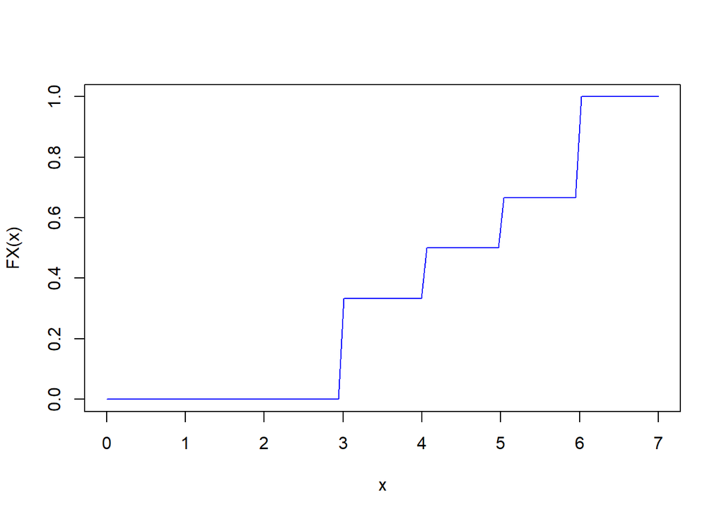

```r
FX=function(x){
  aux=function(t){
    if(t<3) {return(0)}
    if(3<=t & t<4) {return(1/3)}
    if(4<= t & t< 5) {return(1/2)}
    if(5<= t & t< 6) {return(2/3)}
    if(t>=6){return(1)}
    }
  sapply(x,FUN=aux)
}

curve(FX,0,7,col="blue")
```

La función $F_X$ cumple todas las propiedades de una función de distribución discreta:

- $0\leq F_X(x)\leq 1$ para todo $t\in \mathbb{R}.$
- Es solo continua por la derecha, luego es discreta no es continua con dominio $D_X=\{3,4,5,6\}$ que son los valores dónde $P(X=x)=F_X(x)-F_X(x^{-})\not=0$.
- Tiende asintóticamente a 1 cuando $x\to+\infty$ y a 0 cuando $x\to-\infty$.

El Dominio es $D_X=\{3,4,5,6\}$

$P(X=3)=F_X(3)-F_X(3^{-})=F_X(3)-lim_{x\to 3^{-}} F_X(x)=\frac{1}{3}=\frac{1}{3}-0=\frac{1}{3}.$

$P(X=4)=F_X(4)-F_X(4^{-})=F_X(4)-lim_{x\to 4^{-}} F_X(x)=\frac{1}{2}-\frac{1}{3}=\frac{1}{6}.$

$P(X=5)=F_X(5)-F_X(5^{-})=F_X(5)-lim_{x\to 5^{-}} F_X(x)=\frac{2}{3}-\frac{1}{2}=\frac{1}{6}.$

$P(X=6)=F_X(6)-F_X(6^{-})=F_X(6)-lim_{x\to 5^{-}} F_X(x)=1-\frac{2}{3}=\frac{1}{3}.$

$P(X=x)=0$ si $x \not\in\{3,4,5,6\}.$

## 1.3 Problema 3.

La variable aleatoria $Z$ tiene por función de probabilidad:
$$f_Z (x)=
\left\{\begin{array}{ll}
{1\over 3}, & \mbox{si $z=0,1,2$},\\ 0, & \mbox{en los otros
casos.}
\end{array}\right.$$
¿Cuál es la función de distribución para $Z$?

### 1.3.1 Solución

Es discreta así que:

$$F_Z(z)=P(Z\leq z)= \sum_{x=0}^z f_Z (x)=
\left\{\begin{array}{ll}
0 & \mbox{si } x<0 \\
{1\over 3}, & \mbox{si } 0\leq z< 1,\\
{2\over 3}, & \mbox{si } 1\leq z< 2,\\
1 & \mbox{si } 2 \leq x.
\end{array}\right.$$

## 1.4 Problema 4.

Sea $X_n$ una variable aleatoria dependiendo de un valor natural $n$ cuya función de probabilidad es:
$$f(x)=\begin{cases}
k\cdot x, & \mbox{si }x=1,2\ldots,n, \\
0, & \mbox{en caso contrario.}
\end{cases}$$

1. Hallar el valor de $k$ y la función de distribución de $X$.
2. Calcular la probabilidad de que $X$ tome un valor par.

### 1.4.1 Solución

Tenemos que $\sum_{x=1}^n k\cdot x=1$ y tenemos que determinar $k$ en función de $n$, tenemos que

$$1=\sum_{x=1}^n k\cdot x= k\cdot \sum_{x=1}^n = k\cdot \frac{n\cdot
(n+1)}{2}$$

$$k= \frac{2}{n\cdot (n+1)}.$$

Nos piden $P(X\mbox{ sea par})$ si $n$ es par

$$\begin{eqnarray*}
P(X\mbox{ sea par})&=&\sum_{x=1}^{\frac{n}{2}} P(X=2\cdot x)=
\sum_{x=1}^{\frac{n}{2}} \frac{2}{n\cdot (n+1)}\cdot 2\cdot x\\
&=& \frac{2}{n\cdot (n+1)}\cdot2 \cdot \sum_{x=1}^{\frac{n}{2}}
x=
\frac{2}{n\cdot (n+1)}\cdot2 \cdot \frac{\frac{n}{2}\cdot
(\frac{n}{2}+1)}{2}\\
&=& \frac{n\cdot (\frac{n}{2}+1)}{n\cdot(n+1)}=
\frac{\frac{n}{2}+1}{n+1}.
\end{eqnarray*}$$

Se deja como ejercicio el caso en el que $n$ es impar, se tiene que sumar

$$P(X\mbox{ sea par})=\sum_{x=1}^{\frac{n-1}{2}} P(X=2\cdot x).$$

## 1.5 Problema 5.

Un examen tipo test consta de cinco preguntas con tres posibles opciones cada una. Un alumno contesta al azar las cinco cuestiones. Suponiendo que cada respuesta acertada vale dos puntos, hallar la distribución de número de puntos obtenidos por el alumno.

### 1.5.1 Solución

El dominio de la variable $X=$ número de puntos es $D_X=\{0,2,4,6,8,10\}$. Calculamos primero la probabilidad de la variables $Y$= número de preguntas acertadas $D_Y=\{0,1,2,3,4,5\}$

Probabilidad de acertar $n\in D_Y$ preguntas es $P(Y=n)={5 \choose n}\cdot \left(\frac13\right)^n\cdot \left(1-\frac13\right)^{5-n}$

Luego

$$P(X=x)=P\left(Y=\frac{x}{2}\right)=\begin{cases}
\left(\begin{array}{c}5\\\frac{x}{2}\end{array}\right)\cdot
\left(\frac13\right)^\frac{x}{2}\cdot
\left(1-\frac13\right)^{\left(5-\frac{x}{2}\right)}, & \mbox{si
}x=0,2,4,6,8,10 \\
0, & \mbox{en caso contrario.}
\end{cases}$$

# 2 Variables aleatorias continuas

## 2.1 Problema 6.

Verificar que:
$$F_X (t)=
\left\{\begin{array}{ll}
0, & \mbox{si $t<-1$},
\\[0.1cm]
{t+1\over 2}, & \mbox{si $-1\leq
t\leq 1$},
\\[0.1cm]
1, & \mbox{si $t> 1$},
\end{array}\right.$$
es una función de distribución y hallar la función de densidad para $X$. Calcular también $P\left(-{1\over 2}\leq X\leq {1\over 2}\right)$.

### 2.1.1 Solución

La función de densidad de variables aleatorias continuas se puede obtener derivando la función de distribución respecto de la variable $t$:

$$f_X(t)=\left(F_X (t)\right)'=
\left\{\begin{array}{ll}
0, & \mbox{si $t<-1$},
\\[0.1cm]
\left({t+1\over 2}\right)'=\frac12, & \mbox{si $-1\leq
t\leq 1$},
\\[0.1cm]
0, & \mbox{si $t> 1$},
\end{array}\right.=
\left\{\begin{array}{ll}
\frac12, & \mbox{si $-1\leq
t\leq 1$},
\\[0.1cm]
0, & \mbox{ en otro caso},
\end{array}\right.$$

También nos piden

$$P\left(-{1\over 2}\leq X\leq {1\over
2}\right)=F_X\left(\frac12\right)-F_X\left(-\frac12\right)=\frac{\frac12+1}{2}-\frac{-\frac12+1}{2}.=\frac34-\frac14=\frac24=0.5.$$

## 2.2 Problema 7.

Sea $Y$ una variable continua con función de densidad:

$$f_Y(y)=
\left\{\begin{array}{ll}
2(1-y), & \mbox{si $0<y<1$},\\ 0, & \mbox{en los otros
casos}.
\end{array}\right.$$
Hallar la función de distribución $F_Y(t)$.

### 2.2.1 Solución

$$\begin{eqnarray*}
F_Y(y)&=&\int_{-\infty}^y f_Y(t)\cdot dt\\ &=&
\left\{
\begin{array}{ll}
\int_{-\infty}^y 0\cdot dt=0 & \mbox{si } y<0\\
\int_{0}^y 2\cdot (1-t)dt= \left[2\cdot t- t^2\right]_{t=0}^{t=y}=
2\cdot y-y^2, & \mbox{si } 0<y<1,\\
1, & \mbox{en los otros casos}.
\end{array}\right.\\
&=&
\left\{
\begin{array}{ll}
0 & \mbox{si } y<0\\
2\cdot y-y^2, & \mbox{si } 0<y<1,\\
1, & \mbox{en los otros casos}.
\end{array}\right.
\end{eqnarray*}$$

## 2.3 Problema 8.

Verificar que:
$$F_Y(t)=
\left\{\begin{array}{ll}
0, & \mbox{si $t<0$},\\
\sqrt{t}, & \mbox{si $0\leq t\leq 1$},\\ 1, &
\mbox{si $t>1$},
\end{array}\right.$$

es una función de distribución y especificar la función de densidad para $Y$. Usar este resultado para hallar $P\left(-{1\over 2}<Y<{3\over 4}\right)$.

### 2.3.1 Solución

Evidentemente $F_Y(t)>0$ para todo $t$ y $\lim_{t\to-\infty} F_Y(t)=0$ y

$$\lim_{t\to+\infty} F_Y(t)=\int_0^1 t^{\frac12} \cdot dt =
\left[\frac{t^{\frac12+1}}{\frac12+1}\right]_{t=0}^{t=1}=1-0=1.$$

La probabilidad que nos piden es

$$P\left(-{1\over 2}<Y<{3\over 4}\right)=F_Y\left({3\over
4}\right)-F_Y\left(-{1\over
2}\right)=\sqrt{\frac34}-0=\sqrt{\frac34}=\sqrt{0.75}.$$

## 2.4 Problema 9.

Sea $X$ una variable aleatoria con función de densidad:
$$f(x)=\begin{cases}
1-|x|, & \mbox{si }|x|\leq 1,\\
0, & \mbox{en caso contrario.}
\end{cases}$$

1. Representar gráficamente dicha función.
2. Hallar y dibujar la función de distribución.
3. Calcular las siguientes probabilidades: $P(X\geq 0)$ y $P\left(|X|<\frac{1}{2}\right).$

### 2.4.1 Solución

La representaremos con R

```r
fX=function(x){sapply(x,
                      FUN=function(x){if(abs(x)<=1){1-abs(x)}
                        else {0}})
  }
fX(c(-1,-1/2,0,1/2,1))
```

```
## [1] 0.0 0.5 1.0 0.5 0.0
```

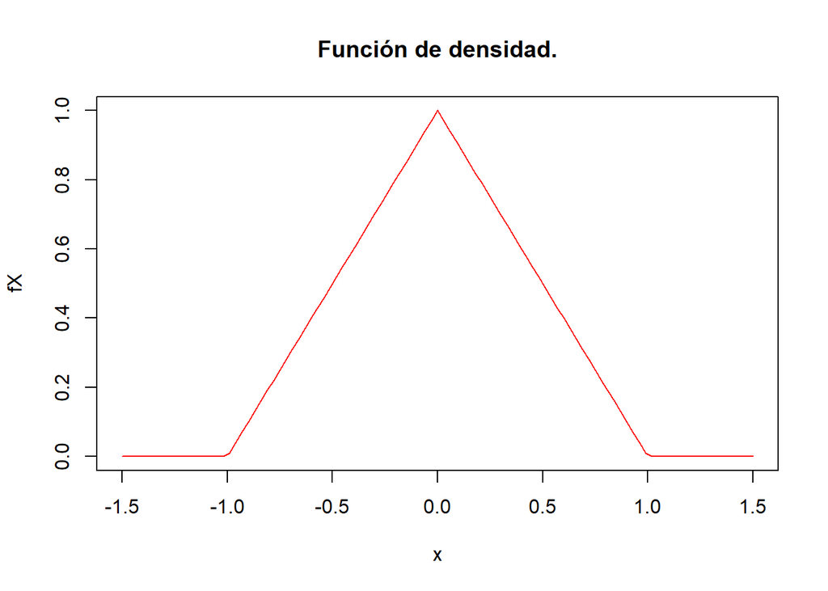

```r
curve(fX,from=-1.5,to=1.5,col="red",ylab="fX",xlab="x",main="Función de densidad.")
```

para calcular la función de distribución hacemos

$$\begin{eqnarray*}
F_X(x)&=&\int_{-\infty}^t f_X(t)\cdot dy\\ &=&
\left\{
\begin{array}{ll}
\int_{-\infty}^t 0\cdot dy=0 & \mbox{si } x<-1\\
\int_{-1}^t 1-|t| \cdot dt= \int_{-1}^t 1+t \cdot dt=
\left[t+\frac{t^2}{2}\right]_{t=-1}^{t=x}= & \mbox{si } -1\leq x\leq
0\\
\int_{-1}^t (1-|t|) \cdot dt= \int_{-1}^0 (1+t)\cdot dt+
\int_{0}^x (1-t) \cdot dt =\frac{1}{2} +
\left[t-\frac{t^2}{2}\right]_{t=0}^{t=x}, & \mbox{si } -\leq x\leq
0,\\
1, & \mbox{si } x\geq 1.
\end{array}\right.
\\
&=&
\left\{
\begin{array}{ll}
0 & \mbox{si } x\leq -1\\
\left(x+\frac{x^2}{2}\right)- \left(-1+\frac{(-1)^2}{2}\right)=
\left(x+\frac{x^2}{2}\right)+ \frac{1}{2}=\frac{x^2+2\cdot x+1}{2}=
\frac{(x+1)^2}{2} & \mbox{si } -1\leq x\leq 0\\
\frac{1}{2}+ \left[\left(x-\frac{x^2}{2}\right)- 0\right]=
\frac{1}{2}+x-\frac{x^2}{2}, & \mbox{si } 0\leq x\leq 1,\\
1, & \mbox{si } x\geq 1.
\end{array}\right.
\\
&=&
\left\{
\begin{array}{ll}
0 & \mbox{si } x\leq -1\\
\frac{(x+1)^2}{2}, & \mbox{si } -1\leq x \leq 0,\\
1-\frac{(1-x)^2}{2}, & \mbox{si } 0\leq x\leq 1,\\
1, & \mbox{si } x\geq 1.
\end{array}\right.
\end{eqnarray*}$$

Su gráfica es

```r
FX=function(x){sapply(x,
                      FUN=function(x){
ifelse(x<=-1,0,ifelse(x>=1,1,ifelse(x<0 & x>-1, (x+1)^2/2, 1/2+x-x^2/2)))
})
}



FX(c(-20,-1,-1/2,0,1/2,1,20))
```

```
## [1] 0.000 0.000 0.125 0.500 0.875 1.000 1.000
```

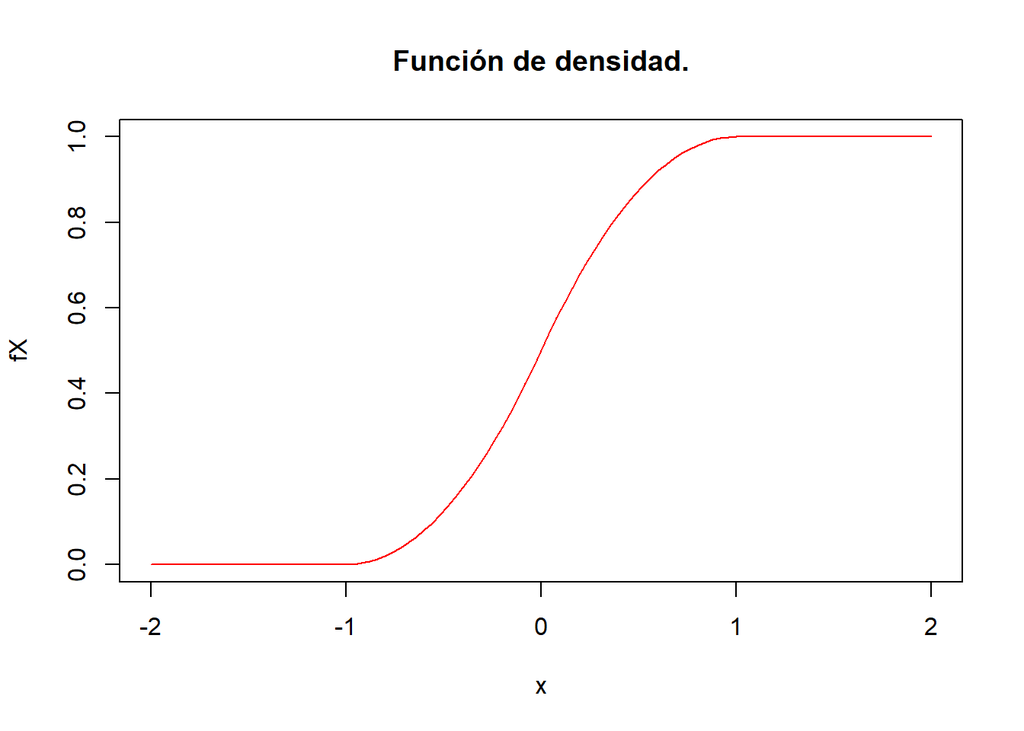

```r
curve(FX,from=-2,to=2,col="red",ylab="fX",xlab="x",main="Función de densidad.")
```

## 2.5 Problema 10.

Hallar la esperanza y la varianza de las variables de los ejercicios anteriores.

### 2.5.1 Solución

Estas integrales se dejan como ejercicio.

# 3 Transformación de variables aleatorias

## 3.1 Problema 11.

A partir de
$$F_X(t)=
\left\{\begin{array}{ll}
0, & \mbox{si $t<-1$},
\\[0.1cm]
{t+1\over 2}, & \mbox{si $-1\leq t\leq
1$},
\\[0.1cm]
1, & \mbox{si $t>1$},
\end{array}\right.$$

hallar la función de distribución para $Y=15+2X$ y la función de densidad para $Y$.

### 3.1.1 Solución

Como $D_X=[-1,1]$ entonces $Y=15+2 X$ varía desde $Y=15+2\cdot (-1)=13$ hasta $Y=15+2\cdot 1=17$ y por lo tanto su dominio es $D_Y=[13,17].$

$$\begin{eqnarray*}
F_Y(y)&=& P(Y\leq y) =P\left(15+2\cdot X\leq y\right)=
P\left(X\leq \frac{y-15}{2}\right)
\\&=&
F_X\left(\frac{y-15}{2}\right)=
\left\{\begin{array}{ll}
0, & \mbox{si } \frac{y-15}{2}<-1,
\\[0.1cm]
{\frac{y-15}{2}+1\over 2}, & \mbox{si } -1\leq \frac{y-15}{2} \leq
1,\\[0.1cm]
1, & \mbox{si } \frac{y-15}{2}>1,
\end{array}\right.
\\&=&
\left\{\begin{array}{ll}
0, & \mbox{si } y<-2-15=13
,
\\[0.1cm]
\frac{y-13}{4}, & \mbox{si } 13\leq y \leq
17,
\\[0.1cm]
1, & \mbox{si } y>17,
\end{array}\right.
\end{eqnarray*}$$

$$f_Y(y)=(F_Y(y))'=
\left\{\begin{array}{ll}
\frac{1}{4}, & \mbox{si } 13\leq y \leq
17,
\\[0.1cm]
0, & \mbox{ en cualquier otro caso}.
\end{array}\right.$$

## 3.2 Problema 12.

Sea $X$ una variable aleatoria continua con función de densidad $f_X(x)$. Consideramos la variable aleatoria $Y=\mathrm{e}^X$. Hallar la función de densidad de la variable aleatoria $Y$, $f_Y(y)$.

### 3.2.1 Solución

Se deja como ejercicio.